# ODE & Dynamic Models Assignment

Author

Marina Kochuten

## The Model

Consider the following model of forest growth (where forest size measured in units of carbon (C))

- dC/dt = r ∗ C for forests where C is below a threshold canopy closure
- dC/dt = g ∗ (1 − C/K) for forests where carbon is at or above the threshold canopy closure
- and K is a carrying capacity in units of carbon

The size of the forest (C), Canopy closure threshold and carrying capacity are all in units of carbon. You could think of the canopy closure threshold as the size of the forest at which growth rates change from exponential to linear You can think of r, as early exponential growth rate and as the linear growth rate once canopy closure has been reached.

## 1. Implement the model as a differential equation

I implemented this model as a differential equation in the R script `forest_growth.R`

## 2. Run the model using ODE Solver

Run the model for 300 years (using the ODE solver) starting with an initial forest size of 10 kg/C, and using the following parameters:

- canopy closure threshold of 50 kgC
- K = 250 kg C (carrying capacity)
- r = 0.01 (exponential growth rate before before canopy closure)
- g = 2 kg/year (linear growth rate after canopy closure)

```r
# Source forest growth function
source(here("R/forest_growth.R"))

# Make a list of parameters
c_initial <- c(C = 10)
times <- seq(from = 1, to = 300)
params <- list(K = 250, r = 0.01, g = 2, thresh = 50)

# Use ode solver
results <- ode(y = c_initial, times = times, func = forest_growth, parms = params)
```

## 3. Graph the results

Graph the trajectory with the parameters as given (e.g no uncertainty)

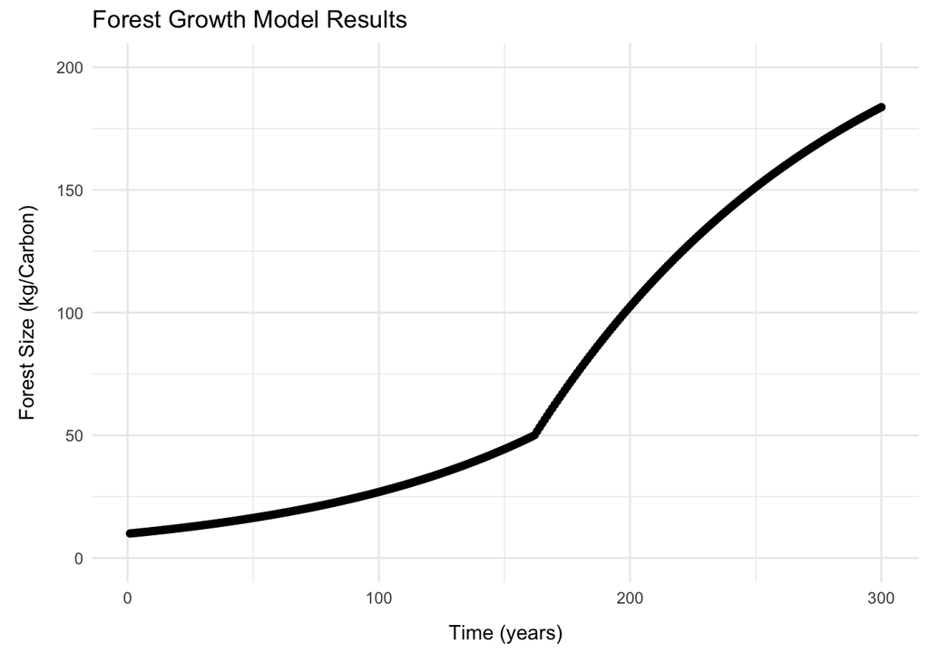

```r
ggplot(results) +
    geom_point(aes(x = time, y = C)) +
    scale_y_continuous(limits = c(0,200)) +
    labs(y = "Forest Size (kg/Carbon)",
         x = "Time (years)",
         title = "Forest Growth Model Results") +
    theme_minimal() +
    theme(
        axis.title.y = element_text(margin = margin(0, 10, 0, 5)),
        axis.title.x = element_text(margin = margin(10, 0, 5, 0))
    )
```

## 4. Run a sobol global sensitivity analysis

Run a sobol global (vary all parameters at the same time) sensitivity analysis that explores how the estimated maximum forest size (e.g maximum of C 300 years), varies with these parameters:

- pre canopy closure growth rate (r)
- post-canopy closure growth rate (g)
- canopy closure threshold and carrying capacity (K)

Assume that parameters are all normally distributed with means as given above and standard deviation of 10% of mean value

```r
##### Set up sample parameters #####
# Set 1
r <- rnorm(mean = 0.01, sd = 0.01 * 0.1, n = 2000)
g <- rnorm(mean = 2, sd = 2 * 0.1, n = 2000)
K <- rnorm(mean = 250, sd = 250 * 0.1, n = 2000)
X1 <- cbind.data.frame(r = r, g = g, K = K)
# Add threshold to parameter list - but we are not varying this one
X1 <- X1 |>
    mutate(thresh = 50)

# Set 2
r <- rnorm(mean = 0.01, sd = 0.01 * 0.1, n = 2000)
g <- rnorm(mean = 2, sd = 2 * 0.1, n = 2000)
K <- rnorm(mean = 250, sd = 250 * 0.1, n = 2000)
X2 <- cbind.data.frame(r = r, g = g, K = K)
# Add threshold to parameter list - but we are not varying this one
X2 <- X2 |>
    mutate(thresh = 50)

# Set any potential negative values to 0
X1 <- X1 |>
    map_df(pmax, 0.0)
X2 <- X2 |>
    map_df(pmax, 0.0)



##### Create Sobel object #####
sens_P <- sobolSalt(model = NULL, X1, X2, nboot = 300)

# Look at parameter sets
head(sens_P$X)
```

```
            [,1]     [,2]     [,3] [,4]
[1,] 0.010134142 1.880935 196.9165   50
[2,] 0.009796624 2.058127 222.9871   50
[3,] 0.009124386 2.262217 231.8461   50
[4,] 0.011766041 1.756819 224.0845   50
[5,] 0.011547052 1.612305 287.2895   50
[6,] 0.008834596 1.823297 208.4241   50
```

```r
# Add names
colnames(sens_P$X) <- c("r", "g", "K", "thresh")

# Look at parameter sets
head(sens_P$X)
```

```
               r        g        K thresh
[1,] 0.010134142 1.880935 196.9165     50
[2,] 0.009796624 2.058127 222.9871     50
[3,] 0.009124386 2.262217 231.8461     50
[4,] 0.011766041 1.756819 224.0845     50
[5,] 0.011547052 1.612305 287.2895     50
[6,] 0.008834596 1.823297 208.4241     50
```

```r
##### Format parameters for ODE Solver #####

# Make sobel parameters into a list
params <- list(r = sens_P$X[1, "r"],
               g = sens_P$X[1, "g"],
               K = sens_P$X[1, "K"],
               thresh = sens_P$X[1, "thresh"])

# Set initial conditions
times <- seq(from = 1, to = 300)
c_initial <- c(C = 10)


##### Test with ODE solver #####
result <- ode(y = c_initial, times = times, func = forest_growth, parms = params)
result <- as.data.frame(result)
```

```r
# Now, I need to build a function that will run the ode solver for all the sobel params and give max forest size

# Metric function
max_c <- function(result) {

    max_c <- max(result$C)

    return(list(max_c))
}

# test
max_c(result)
```

```
[[1]]
[1] 158.4106
```

```r
# Wrapper function
wrapper <- function(K, g, r, thresh, c_initial, times, forest_growth_func, max_c_func) {
    parms <- list(r = r, K = K, g = g, thresh = thresh)
    result <- ode(y = c_initial, times = times, func = forest_growth_func, parms = parms, method="euler")
    colnames(result) <- c("time", "C")

    # get metrics
    metrics <- max_c_func(as.data.frame(result))
    return(metrics)
}


# test
wrapper(
  r = 0.01, K = 250, g = 2, thresh = 50, c_initial = c(C = 10), times = seq(from = 1, to = 300),
  forest_growth_func = forest_growth, max_c_func = max_c
)
```

```
[[1]]
[1] 183.4948
```

```r
# List out all parameters
params <- list(r = sens_P$X[, "r"],
               g = sens_P$X[, "g"],
               K = sens_P$X[, "K"],
               thresh = sens_P$X[, "thresh"])

# Use pmap to use ode on sobel params
allresults <- params %>% pmap(wrapper, c_initial = c(C = 10), times = seq(from = 1, to = 300), forest_growth_func = forest_growth, max_c_func = max_c)

# extract out results from pmap into a data frame
allres <- allresults %>%
  map_dfr(~ tibble(max_c = .x[[1]]))
```

## 5. Graph the results of the sensitivity analysis

… as a box plot of maximum forest size and record the two Sobol indices (S and T).

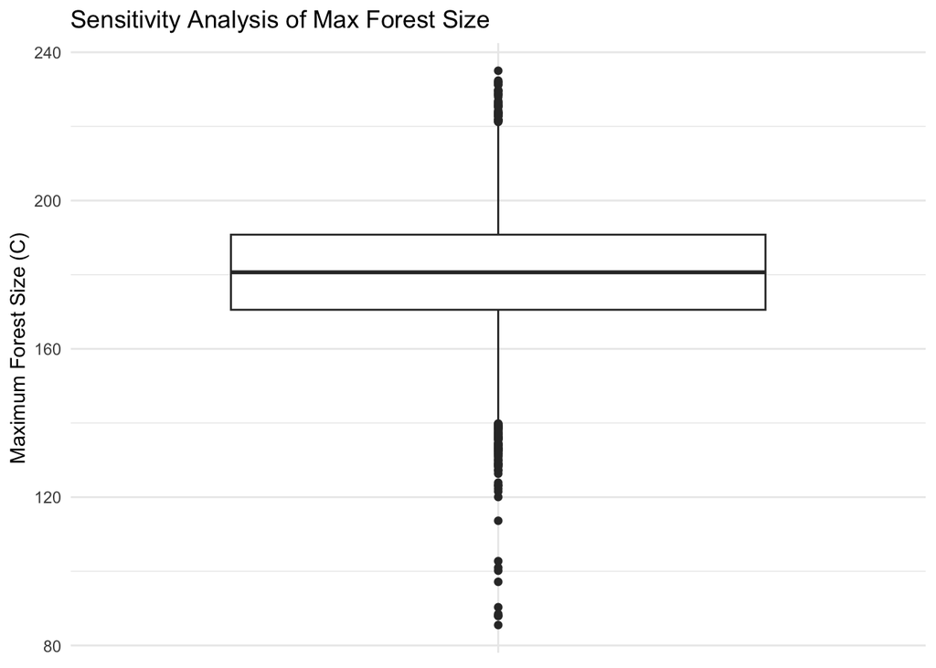

```r
# Get max forest size values
max_forest <- sens_P$y


tmp <- allres %>% pivot_longer(cols = everything(), names_to = "max_forest", values_to = "value")

# Box plot of max forest size with varied parameters
ggplot(tmp) +
  geom_boxplot(aes(x = max_forest, y = value)) +
  labs(title = "Sensitivity Analysis of Max Forest Size",
       y = "Maximum Forest Size (C)",
       x = "") +
    scale_y_continuous() +
  theme_minimal() +
    theme(axis.title.x = element_blank(),
          axis.text.x = element_blank())
```

```r
# Record two sobel indices

sens_P_max <- sensitivity::tell(sens_P, allres$max_c)

# first-order indices (main effect without co-variance)
rownames(sens_P_max$S) <- c("r", "g", "K", "thresh")
print(sens_P_max$S)
```

```
          original          bias std. error   min. c.i.  max. c.i.
r       0.37488384 -0.0009930551 0.02428875  0.32636020 0.42973340
g       0.22470086 -0.0009589387 0.02034008  0.18686840 0.26587506
K       0.36364715  0.0003512269 0.01938680  0.32273170 0.40319395
thresh -0.01480503 -0.0006449015 0.02074210 -0.05426436 0.02639541
```

```r
# total sensitivity index -note that this partitions the output variance
rownames(sens_P_max$T) <- c("r", "g", "K", "thresh")
print(sens_P_max$T)
```

```
           original         bias   std. error     min. c.i.    max. c.i.
r      3.963576e-01 1.062817e-03 1.593840e-02  3.646644e-01 4.250995e-01
g      2.393814e-01 9.099455e-04 1.075964e-02  2.156232e-01 2.600672e-01
K      3.958975e-01 1.638846e-03 1.761020e-02  3.602259e-01 4.267809e-01
thresh 8.271162e-14 2.721904e-13 8.793855e-13 -1.975501e-12 1.420254e-12
```

## 6. Discussion

In 2-3 sentences, discuss what the results of your simulation might mean. (For example think about how what parameters climate change might influence)

Looking at the sobel indices, the max forest size is the most sensitive to r, the exponential growth rate before before canopy closure, and carrying capacity K. Climate change could impact both parameters. For example, increased temperatures or drought might reduce r by stressing young forests. Also, increasing frequent disturbances such as fire could decrease K.